# Data Science Capstone Milestone Report

Jon Ting

24/08/2020

```r
knitr::opts_chunk$set(echo=T)
suppressPackageStartupMessages(library(downloader))
suppressPackageStartupMessages(library(ngram))
suppressPackageStartupMessages(library(tm))
suppressPackageStartupMessages(library(wordcloud2))
suppressPackageStartupMessages(library(htmlwidgets))
suppressPackageStartupMessages(library(webshot))
suppressPackageStartupMessages(library(ggplot2))
```

## Introduction

This is a milestone report for the project regarding analysis of the SwiftKey data set.

The purpose for this report is to:

- Demonstrate that the Swiftkey data downloaded from Coursera website has been loaded into R.
- Create a basic report of summary statistics about the datasets.
- Report interesting findings about the datasets.
- Present plans to create a prediction algorithm and Shiny app from the data.

## Load and Summarize Data

The Swiftkey data contains blog entries, news entries, and twitter feeds in four different languages, which are German, English, Russian, and Finnish, respectively. The English dataset is processed with reference to the other 3 datasets to match the foreign language words embedded in the data.

```r
# Download and extract data
Url <- "https://d396qusza40orc.cloudfront.net/dsscapstone/dataset/Coursera-SwiftKey.zip"
if(!file.exists("../Coursera-SwiftKey.zip")) { download.file(Url, destfile="../Coursera-SwiftKey.zip", mode="wb") }
if(!file.exists("../final")) { unzip(zipfile="../Coursera-SwiftKey.zip", exdir="../") }

# Load data
blogs <- readLines("../final/en_US/en_US.blogs.txt", skipNul=T, encoding="UTF-8")
news <- readLines("../final/en_US/en_US.news.txt", skipNul=T, encoding="UTF-8")
twits <- readLines("../final/en_US/en_US.twitter.txt", skipNul=T, encoding="UTF-8")

# Size of the en_US datasets (bytes)
blogs_size <- file.info("../final/en_US/en_US.blogs.txt")$size / 1024
news_size <- file.info("../final/en_US/en_US.news.txt")$size / 1024
twits_size <- file.info("../final/en_US/en_US.twitter.txt")$size / 1024

# Basic summary of each dataset
blogs_summ <- summary(blogs)
news_summ <- summary(news)
twits_summ <- summary(twits)

# Summary of number of characters in each dataset
blogs_cc <- summary(nchar(blogs))
news_cc <- summary(nchar(news))
twits_cc <- summary(nchar(twits))

# Number of lines in each dataset
blogs_lc <- length(blogs)
news_lc <- length(news)
twits_lc <- length(twits)

# Number of words in each dataset
blogs_wc <- wordcount(blogs)
news_wc <- wordcount(news)
twits_wc <- wordcount(twits)

# Report the summaries
rbind(blogs_summ, news_summ, twits_summ)
```

```
##            Length    Class       Mode
## blogs_summ "899288"  "character" "character"
## news_summ  "77259"   "character" "character"
## twits_summ "2360148" "character" "character"
```

```r
rbind(blogs_cc, news_cc, twits_cc)
```

```
##          Min. 1st Qu. Median      Mean 3rd Qu.  Max.
## blogs_cc    1      47    156 229.98695     329 40833
## news_cc     2     111    186 202.42830     270  5760
## twits_cc    2      37     64  68.68054     100   140
```

```r
data.frame(c("Blogs", "News", "Twits"),
           "File size"=c(blogs_size, news_size, twits_size),
           "Line count"=c(blogs_lc, news_lc, twits_lc),
           "Word count"=c(blogs_wc, news_wc, twits_wc),
           row.names=1)
```

```
##       File.size Line.count Word.count
## Blogs  205234.4     899288   37334131
## News   200988.2      77259    2643969
## Twits  163188.8    2360148   30373583
```

## Basic Plots

The smaller subset of each dataset is created randomly to ease the subsequent processing steps. A corpus is created from the data subsets by:

- removing all URLs and everything that is not an alphabet or space,
- converting the remaining alphabets to lower case,
- removing profane words, and
- generating plain text corpus.

The list of profane words is obtained from [Google](https://code.google.com/archive/p/badwordslist/downloads). Entries that contain symbols that might contaminate regular expressions are removed.

```r
# Create corpus from dataset subsets
subset_size <- 10000
blogs_sub <- sample(blogs, subset_size)
news_sub <- sample(news, subset_size)
twits_sub <- sample(twits, subset_size)
corp <- VCorpus(VectorSource(c(blogs_sub, news_sub, twits_sub)))
saveRDS(corp, file="./messy_corp.rds")

# Clean the corpus
delPat <- content_transformer(function(x, pattern) gsub(pattern, " ", x))
profane_words <- read.delim("./badwords.txt", header=F)[,1]
corp <- tm_map(x=corp, FUN=delPat, "(f|ht)tp(s?)://(.*)[.][a-z]+")
corp <- tm_map(x=corp, FUN=delPat, "[^a-zA-Z ]")
corp <- tm_map(x=corp, FUN=removePunctuation)
corp <- tm_map(x=corp, FUN=removeNumbers)
corp <- tm_map(x=corp, FUN=content_transformer(FUN=tolower))  # Functions are nested to avoid error
# corp <- tm_map(x=corp, FUN=removeWords, stopwords(kind="en"))  # Produce less intuitive n-grams
corp <- tm_map(x=corp, FUN=removeWords, profane_words)
# corp <- tm_map(x=corp, FUN=stemDocument)  # Stemming produce less intuitive n-grams
corp <- tm_map(x=corp, FUN=stripWhitespace)
corp <- tm_map(x=corp, FUN=PlainTextDocument)
saveRDS(corp, file="./corp.rds")
```

In the field of Natural Language Processing, n-gram is a contiguous sequence of n items from a given sequence of text or speech. The sentences and phrases in the corpus are then broken into pairs of words or n-grams through tokenization:

```r
# Define tokenization functions
bigram <- function(x) unlist(lapply(ngrams(words(x), 2), paste, collapse=" "), use.names=FALSE)
trigram <- function(x) unlist(lapply(ngrams(words(x), 3), paste, collapse=" "), use.names=FALSE)

# Remove sparse terms to aid generalization, tune sparse parameter to return a matrix of appropriate size
docTermMat1 <- removeSparseTerms(x=TermDocumentMatrix(corp), sparse=0.99)
docTermMat2 <- removeSparseTerms(x=TermDocumentMatrix(corp, control=list(tokenize=bigram)), sparse=0.9993)
docTermMat3 <- removeSparseTerms(x=TermDocumentMatrix(corp, control=list(tokenize=trigram)), sparse=0.99995)

# Create frequency dataframes
freq1 <- sort(rowSums(as.matrix(docTermMat1)), decreasing=T)
freq2 <- sort(rowSums(as.matrix(docTermMat2)), decreasing=T)
freq3 <- sort(rowSums(as.matrix(docTermMat3)), decreasing=T)
df1 <- data.frame(grm=names(freq1), frq=freq1)
df2 <- data.frame(grm=names(freq2), frq=freq2)
df3 <- data.frame(grm=names(freq3), frq=freq3)
```

The frequencies of the more common unigrams, bigrams, and trigrams in the corpus are visualized using word clouds and histograms:

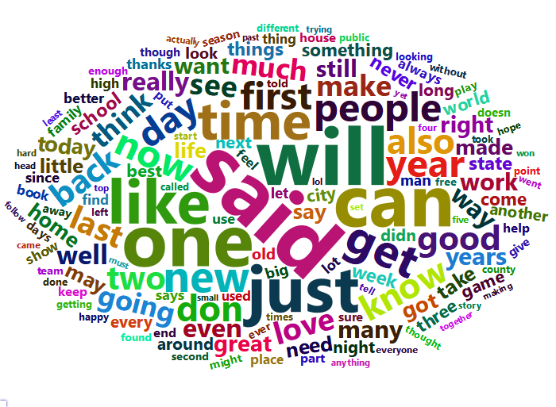

```r
# Word clouds
cloud1 = wordcloud2(data=df1, size=0.6, fontWeight=700, shape='circle', color='random-dark')
cloud2 = wordcloud2(data=df2, size=1.2, fontWeight=600, shape='circle', color='random-dark')
cloud3 = wordcloud2(data=df3, size=0.7, fontWeight=500, shape='circle', color='random-dark')
saveWidget(widget=cloud1, file="cloud1.html", selfcontained=F)
saveWidget(widget=cloud2, file="cloud2.html", selfcontained=F)
saveWidget(widget=cloud3, file="cloud3.html", selfcontained=F)
webshot(url="cloud1.html", file="cloud1.png", vwidth=700, vheight=500, delay=10)
```

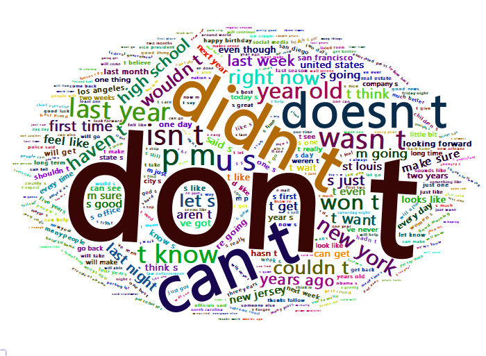

```r
webshot(url="cloud2.html", file="cloud2.png", vwidth=700, vheight=500, delay=10)
```

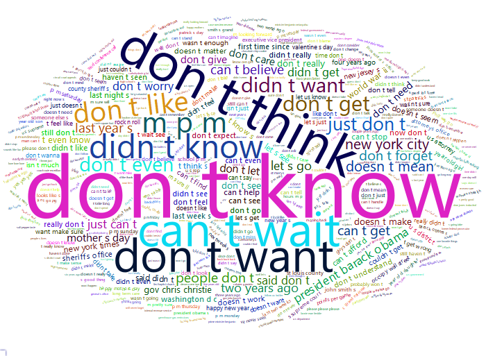

```r
webshot(url="cloud3.html", file="cloud3.png", vwidth=700, vheight=500, delay=10)
```

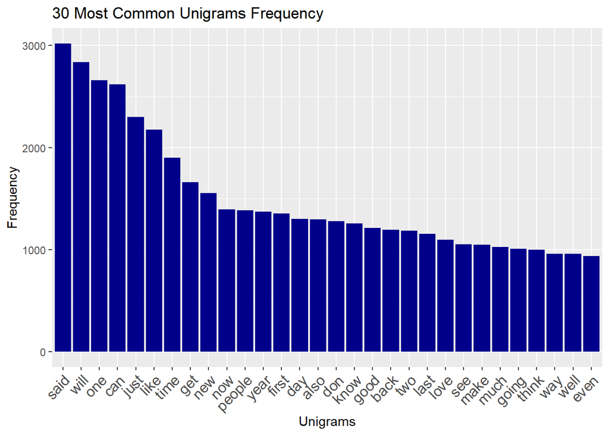

```r
# Histograms
ggplot(df1[1:30, ], aes(reorder(grm, -frq), frq)) +
  labs(title="30 Most Common Unigrams Frequency", x="Unigrams", y="Frequency") +
  theme(axis.text.x=element_text(angle=45, size=12, hjust=1)) +
  geom_bar(stat="identity", fill="darkblue")
```

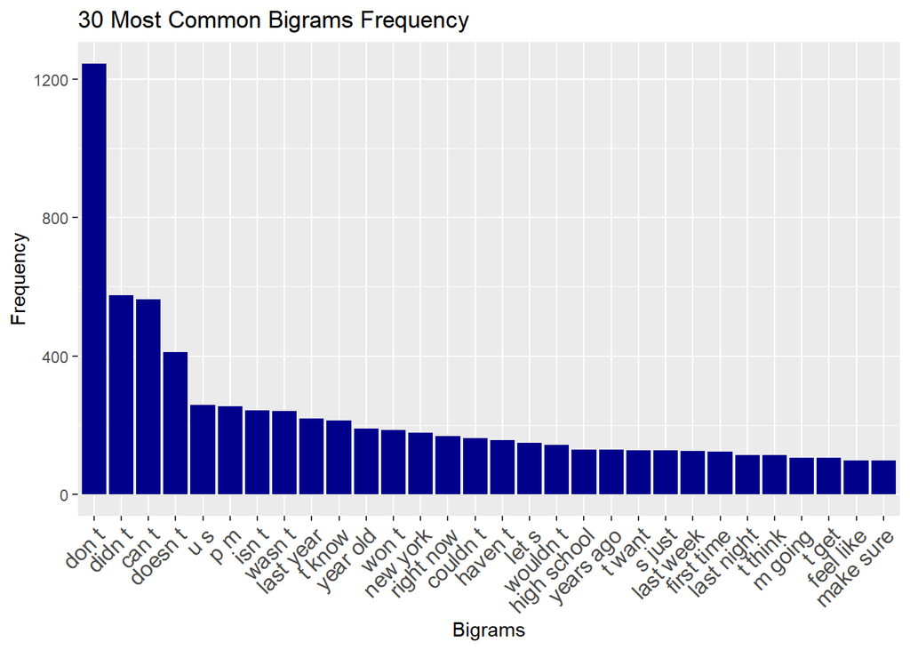

```r
ggplot(df2[1:30, ], aes(reorder(grm, -frq), frq)) +
  labs(title="30 Most Common Bigrams Frequency", x="Bigrams", y="Frequency") +
  theme(axis.text.x=element_text(angle=45, size=12, hjust=1)) +
  geom_bar(stat="identity", fill="darkblue")
```

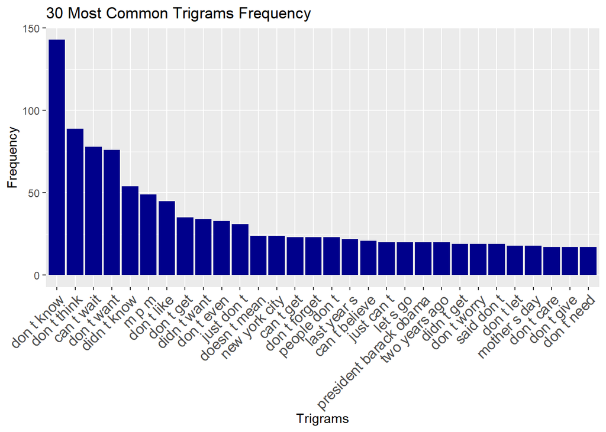

```r
ggplot(df3[1:30, ], aes(reorder(grm, -frq), frq)) +
  labs(title="30 Most Common Trigrams Frequency", x="Trigrams", y="Frequency") +
  theme(axis.text.x=element_text(angle=45, size=12, hjust=1)) +
  geom_bar(stat="identity", fill="darkblue")
```

## Interesting Findings

The exploratory data analysis on the English dataset resulted in the following findings:

- Blog entries have about the same length as news entries on average, which are much longer than twitter feeds.
- The abundance of the n-grams is generally inversely proportional to their length.
- A lot of the bigrams consist of words that originally contain apostrophe.
- Word stemming results in less intuitive longer n-grams.

## Basic Project Plan

The plan to continue the project is as follow:

1. Use n-gram models to predict the next word in a sequence of words:
   - Tokenize the corpus into n-grams and store in document term matrices.
   - Converts the matrices to dataframes of frequencies.
   - Implement a predictive model based on these dataframes.
   - Predict the next word by choosing the most frequent word in the (n+1)-grams based on the input n-grams text.
2. create a Shiny app that allows its users to provide a text input and display an output of the predicted upcoming word.
3. Deploy the app and present a reproducible pitch.